# Results tested at 6 nodes (consistently affected genes)

## 7) Compute clusters driving VAE

In the next section, we use information about the VAE nodes to compute clusters regarding the latent space.

```
--------------------------------------------------------------------------------
                                   Set 1	20
--------------------------------------------------------------------------------
--------------------------------------------------------------------------------
                                   Set 2	65
--------------------------------------------------------------------------------
--------------------------------------------------------------------------------
                                   Set 3	132
--------------------------------------------------------------------------------
--------------------------------------------------------------------------------
                                   Set 4	29
--------------------------------------------------------------------------------
--------------------------------------------------------------------------------
                                   Set 5	182
--------------------------------------------------------------------------------
--------------------------------------------------------------------------------
                                   Set 6	82
--------------------------------------------------------------------------------
```

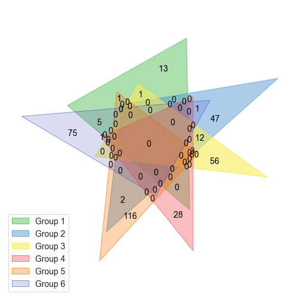

```
--------------------------------------------------------------------------------
plot_scatters	You have more than three latent nodes: 	6
 We will only be plotting the first three
--------------------------------------------------------------------------------
```

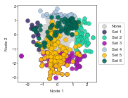

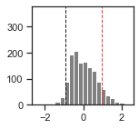

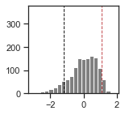

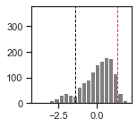

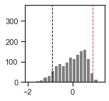

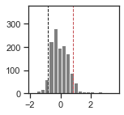

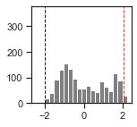

```python
def get_q1_q3(node_idx):
    iqr_val = 0.95 * stats.iqr(vae_data[:, node_idx])
    q1_genes_idxs = np.where(vae_data[:, node_idx] <= -1.25)[0] # (np.mean(vae_data[:, node_idx]) - iqr_val))[0]
    q3_genes_idxs = np.where(vae_data[:, node_idx] >= 1.25)[0] #(np.mean(vae_data[:, node_idx]) + iqr_val))[0]
    return q1_genes_idxs, q3_genes_idxs

# -----------------------------------------------------------------------------------
#                         Find the genes driving the latent space
# -----------------------------------------------------------------------------------

n_clusters = 6
# Get the indexs for each of the q1 and q3 for each node
q1_n0_idxs, q3_n0_idxs = get_q1_q3(0)
q1_n1_idxs, q3_n1_idxs = get_q1_q3(1)
q1_n2_idxs, q3_n2_idxs = get_q1_q3(2)

# Create a list of the indexs
vae_set_idxs = [
    q1_n0_idxs, q3_n0_idxs,
    q1_n1_idxs, q3_n1_idxs,
    q1_n2_idxs, q3_n2_idxs
]

vae_set_labels = ['Set 1', 'Set 2', 'Set 3', 'Set 4', 'Set 5', 'Set 6']

# Get all the driver and non-driver idxs
non_driver_idxs = []
driver_idxs = []
for i, ids in enumerate(vae_set_idxs):
    vae_mse.u.dp([vae_set_labels[i], len(ids)])
    driver_idxs += list(ids)

for i in range(0, len(df)):
    if i not in driver_idxs:
        non_driver_idxs.append(i)
# -----------------------------------------------------------------------------------
#                         Plot a VENN of how the genes in teh clusters overlap
# -----------------------------------------------------------------------------------

gene_sets = [[], [], [], [], [], []]

for i, g in enumerate(df[gene_name].values):
    ci = 0
    for gene_set in vae_set_idxs:
        for j in gene_set:
            if i == j:
                gene_sets[ci].append(g)
        ci += 1

set_sets = []
for g in gene_sets:
    if len(g) > 1:
        set_sets.append(set(g))

set_labels = venn.get_labels(set_sets)
vae_set_labels_l = [s.replace('Set', 'Group') for s in vae_set_labels]
vae_set_genes_len_dict = {}
vae_set_genes_dict = {}
for i, l in enumerate(vae_set_labels):
    vae_set_genes_dict[l] = gene_sets[i]
    vae_set_genes_len_dict[l] = len(gene_sets[i])

venn.venn6(set_labels, names=vae_set_labels_l)
save_fig('gene_sets.svg')
plt.show()


vae_set_genes_as_list = []
for set_name in vae_set_labels:
    vae_set_genes_as_list.append(vae_set_genes_dict.get(set_name))

sorted_sets_by_size = {k: v for k, v in sorted(vae_set_genes_len_dict.items(), key=lambda item: item[1])}
gene_set_labels_unique = []
for g in df[gene_name].values:
    found = False
    for label, values in sorted_sets_by_size.items():
        gene_group = vae_set_genes_dict[label]
        for g_l in gene_group:
            if g_l == g:
                gene_set_labels_unique.append(label)
                found = True
                break
        if found:
            break
    if not found:
        gene_set_labels_unique.append(None)
df['GeneDriverSet'] =  gene_set_labels_unique

# We also want to add each of the gene sets
gene_labels = [[], [], [], [], [], []]
for g in df[gene_name].values:
    for i, label in enumerate(vae_set_labels):
        found = False
        gene_group = vae_set_genes_dict[label]
        for g_l in gene_group:
            if g == g_l:
                gene_labels[i].append(True)
                found = True
                break
        if not found:
            gene_labels[i].append(False)
for i, label in enumerate(vae_set_labels):
    df[label] = gene_labels[i]


# -----------------------------------------------------------------------------------
#                         Plot the genes on a scatter plot
# -----------------------------------------------------------------------------------
vae_vis.plot_values_on_scatters(df, gene_name, vae_set_labels,
                            vae_set_genes_as_list, vae_data=vae_data, output_dir=fig_dir, plt_bg=True,
                            title=f'VAE gene driver sets {experiment_name}',
                            show_plt=True, save_fig=True)

# -----------------------------------------------------------------------------------
#                         Plot histograms of the VAE nodes with cutoffs used above
# -----------------------------------------------------------------------------------
for n in range(0, num_nodes):
    x = vae_data[:,n]
    iqr_val = 1.0 * stats.iqr(x)
    plt.hist(vae_data[:,n], bins=20, color='grey')
    plt.ylim(0, 380)
    plt.axvline(x.mean() - iqr_val, color='k', linestyle='dashed', linewidth=1)
    plt.axvline(x.mean() + iqr_val, color='r', linestyle='dashed', linewidth=1)
    save_fig(f'hist-{n}')
    plt.show()
```

```python
hox_genes = sc_genes
forebrain_genes = fb_genes
h3cols = []
fb_rna_cols = []
sc_rna_cols = []

# Do it in this way so they are correctly ordered
for c in df.columns:
    if 'H3K27me' in c and 'signal' in c:
        h3cols.append(c)
    elif 'wt' in c:
        if 'fb' in c:
            fb_rna_cols.append(c)
        if 'sc' in c:
            sc_rna_cols.append(c)
for c in df.columns:
    if 'ko' in c:
        if 'fb' in c:
            fb_rna_cols.append(c)
        if 'sc' in c:
            sc_rna_cols.append(c)

def plot_gene_boxplot(df, title, cluster_id, cols, idxs):
    idxs = idxs[cluster_id]
    boxplot = Boxplot(df, gene_name, cols[0])
    box_df = boxplot.format_data_for_boxplot(df, cols, gene_name, df[gene_name].values[idxs])
    is_hox = []
    sns.set_style("white")
    for c in box_df['Samples'].values:
        if 'Hox' in c:
            is_hox.append('Hox')
        else:
            is_hox.append('Hox like')
    box_df['is_hox'] = is_hox

    boxplot = Boxplot(box_df, "Conditions", "Values", add_stats=False, add_dots=False, figsize=(1,0.5),
                       order=cols)
    boxplot.palette = sci_colour

    ax = boxplot.plot()
    plt.title(title)
    ax.set_ylim(0, 12)
    sns.set_style("white")
    c = 0
    for b in ax.artists:
        if c < len(cols)/2:
            b.set_facecolor(wt_colour)
        else:
            b.set_facecolor(ko_colour)
        c += 1
    save_fig(f'{title}')

    plt.show()

avgs_fb = [['wt11fb1',
         'wt11fb2'],
         ['wt13fb1',
         'wt13fb2'],
         ['wt15fb1',
         'wt15fb2'],
         ['wt18fb1',
         'wt18fb2'],
         ['ko11fb1',
         'ko11fb2'],
         ['ko13fb1',
         'ko13fb2'],
         ['ko15fb1',
         'ko15fb2'],
         ['ko18fb1',
         'ko18fb2']]

avgs_sc = [['wt11sc1',
         'wt11sc2'],
         ['wt13sc1',
         'wt13sc2'],
         ['wt15sc1',
         'wt15sc2'],
         ['wt18sc1',
         'wt18sc2'],
         ['ko11sc1',
         'ko11sc2'],
         ['ko13sc1',
         'ko13sc2'],
         ['ko15sc1',
         'ko15sc2'],
         ['ko18sc1',
         'ko18sc2']]

avgs_hb = [['wt11hb1',
         'wt11hb2'],
         ['wt13hb1',
         'wt13hb2'],
         ['wt15hb1',
         'wt15hb2'],
         ['wt18hb1',
         'wt18hb2'],
         ['ko11hb1',
         'ko11hb2'],
         ['ko13hb1',
         'ko13hb2'],
         ['ko15hb1',
         'ko15hb2'],
         ['ko18hb1',
         'ko18hb2']]

avgs_mb = [['wt11mb1',
         'wt11mb2'],
         ['wt13mb1',
         'wt13mb2'],
         ['wt15mb1',
         'wt15mb2'],
         ['wt18mb1',
         'wt18mb2'],
         ['ko11mb1',
         'ko11mb2'],
         ['ko13mb1',
         'ko13mb2'],
         ['ko15mb1',
         'ko15mb2'],
         ['ko18mb1',
         'ko18mb2']]
avgs_df = pd.DataFrame()
avgs_df[gene_name] = df[gene_name].values
fb_cols = []
for f in avgs_fb:
    new_col = f'{f[0][:2]} {f[0][2:4]} FB'
    avgs_df[new_col] = (df[f[0]].values + df[f[1]].values) / 2.0
    fb_cols.append(new_col)

sc_cols = []
for f in avgs_sc:
    new_col = f'{f[0][:2]} {f[0][2:4]} SC'
    avgs_df[new_col] = (df[f[0]].values + df[f[1]].values) / 2.0
    sc_cols.append(new_col)

mb_cols = []
for f in avgs_mb:
    new_col = f'{f[0][:2]} {f[0][2:4]} MB'
    avgs_df[new_col] = (df[f[0]].values + df[f[1]].values) / 2.0
    mb_cols.append(new_col)

hb_cols = []
for f in avgs_hb:
    new_col = f'{f[0][:2]} {f[0][2:4]} HB'
    avgs_df[new_col] = (df[f[0]].values + df[f[1]].values) / 2.0
    hb_cols.append(new_col)

for i, gs in enumerate(vae_set_idxs):
    plot_gene_boxplot(avgs_df, f'Cluster {i + 1} FB', i, fb_cols, vae_set_idxs)
    plot_gene_boxplot(avgs_df, f'Cluster {i + 1} MB', i, mb_cols, vae_set_idxs)
    plot_gene_boxplot(avgs_df, f'Cluster {i + 1} HB', i, hb_cols, vae_set_idxs)
    plot_gene_boxplot(avgs_df, f'Cluster {i + 1} SC', i, sc_cols, vae_set_idxs)
```

[output not shown]

[output not shown]

[output not shown]

[output not shown]

[output not shown]

[output not shown]

[output not shown]

[output not shown]

[output not shown]

[output not shown]

[output not shown]

[output not shown]

[output not shown]

[output not shown]

[output not shown]

[output not shown]

[output not shown]

[output not shown]

[output not shown]

[output not shown]

[output not shown]

[output not shown]

[output not shown]

[output not shown]

[output not shown]

## Plot the heatmaps

```python
def plot_vae_rna_cols(vis_df, cols, num_nodes, fb_logfc, mb_logfc, hb_logfc, sc_logfc,
                      h3k27me3_fb_e11, h3k27me3_fb_e18, h3k27me3_hb_e11, h3k27me3_hb_e18, title='Heatmap',
                      num_values=10):
    vae_cols = [f'VAE{i}' for i in range(0, num_nodes)]

    sns.set_style("ticks")
    for r_i, r_c in enumerate(cols):
        for direction in ['up', 'down']:
            # First add the bottom ones
            fig, ax = plt.subplots()
            sns.set(rc={'figure.figsize': (3.5, 2), 'font.family': 'sans-serif',
            'font.sans-serif': 'Arial', 'font.size': 6}, style="ticks")
            rcm_df_sorted = vis_df.sort_values(by=[r_c])
            if direction == 'up':
                rcm_df_tails = rcm_df_sorted.nlargest(num_values, r_c)
            else:
                rcm_df_tails = rcm_df_sorted.nsmallest(num_values, r_c)
            # Add the smallest and the largest
            # first heatmap
            N = len(rcm_df_tails)
            ax.set_xlim(-0.5, 7.5)
            ax.set_xticks([0, 1, 2, 3, 4, 5, 6, 7])
            ax.set_xticklabels(['FB', 'MB', 'HB', 'SC',
                                'FB e11.5', 'FB e18.5', 'HB e11.5', 'HB e18'])
            ax.set_yticks(range(N))
            ax.set_yticklabels(list(rcm_df_tails[gene_name].values))
            ax.set_ylabel('Genes')

            max_hk3 = 35
            max_rna = 10
            min_rna = -10
            cmap_rna = 'seismic'
            cmap_hk3 = 'Greens'
            im1 = ax.imshow(np.vstack([rcm_df_tails[fb_logfc], rcm_df_tails[fb_logfc]]).T,
                            aspect='auto',
                            extent=[-0.5, 0.5, -0.5, N - 0.5], vmin=min_rna, vmax=max_rna,
                            origin='lower', cmap=cmap_rna)
            im1 = ax.imshow(np.vstack([rcm_df_tails[mb_logfc], rcm_df_tails[mb_logfc]]).T,
                            aspect='auto',
                            extent=[0.5, 1.5, -0.5, N - 0.5], vmin=min_rna, vmax=max_rna,
                            origin='lower', cmap=cmap_rna)
            im1 = ax.imshow(np.vstack([rcm_df_tails[hb_logfc], rcm_df_tails[hb_logfc]]).T,
                aspect='auto',
                extent=[1.5, 2.5, -0.5, N - 0.5], vmin=min_rna, vmax=max_rna,
                origin='lower', cmap=cmap_rna)
            # Now add in the H3K27me3 ones
            im1 = ax.imshow(np.vstack([rcm_df_tails[sc_logfc], rcm_df_tails[sc_logfc]]).T,
                aspect='auto',
                extent=[2.5, 3.5, -0.5, N - 0.5], vmin=min_rna, vmax=max_rna,
                origin='lower', cmap=cmap_rna)

            im3 = ax.imshow(np.vstack([rcm_df_tails[h3k27me3_fb_e11], rcm_df_tails[h3k27me3_fb_e11]]).T,
                            aspect='auto',
                            extent=[3.5, 4.5, -0.5, N - 0.5], vmin=0, vmax=max_hk3,
                            origin='lower', cmap=cmap_hk3)

            im3 = ax.imshow(np.vstack([rcm_df_tails[h3k27me3_fb_e18], rcm_df_tails[h3k27me3_fb_e18]]).T,
                aspect='auto',
                extent=[4.5, 5.5, -0.5, N - 0.5], vmin=0, vmax=max_hk3,
                origin='lower', cmap=cmap_hk3)

            im3 = ax.imshow(np.vstack([rcm_df_tails[h3k27me3_hb_e11], rcm_df_tails[h3k27me3_hb_e11]]).T,
                            aspect='auto',
                            extent=[5.5, 6.5, -0.5, N - 0.5], vmin=0, vmax=max_hk3,
                            origin='lower', cmap=cmap_hk3)

            im3 = ax.imshow(np.vstack([rcm_df_tails[h3k27me3_hb_e18], rcm_df_tails[h3k27me3_hb_e18]]).T,
                aspect='auto',
                extent=[6.5, 7.5, -0.5, N - 0.5], vmin=0, vmax=max_hk3,
                origin='lower', cmap=cmap_hk3)

            cbar1 = fig.colorbar(im1, ax=ax, label='RNA logFC')
            cbar2 = fig.colorbar(im3, ax=ax, label='H3K27me3 signal')

            fig.tight_layout()
            plt.xticks(rotation=45, horizontalalignment='right')
            plt.title(f'{title} {r_c}')
            save_fig(f'{title.replace(" ", "_")}_{direction}_{r_c}')
```

[figure not shown]

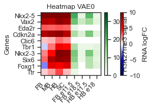

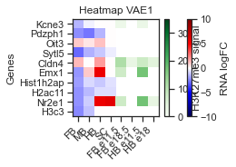

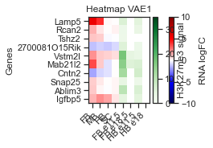

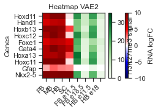

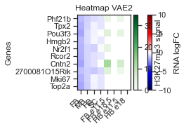

```python
h3k27me3_fb_e11 = [c for c in df.columns if '10.5' in c and 'forebrain' in c and 'H3K27me3' in c and 'signal' in c and 'median' not in c][0]
h3k27me3_fb_e18 = [c for c in df.columns if '16.5' in c and 'forebrain' in c and 'H3K27me3' in c and 'signal' in c and 'median' not in c][0]

h3k27me3_hb_e11 = [c for c in df.columns if '10.5' in c and 'hindbrain' in c and 'H3K27me3' in c and 'signal' in c and 'median' not in c][0]
h3k27me3_hb_e18 = [c for c in df.columns if '16.5' in c and 'hindbrain' in c and 'H3K27me3' in c and 'signal' in c and 'median' not in c][0]

plot_vae_rna_cols(df, ["VAE0", "VAE1", "VAE2"], 3,
                    'Log2FC FB',
                    'Log2FC MB',
                    'Log2FC HB',
                    'Log2FC SC',
                     h3k27me3_fb_e11, h3k27me3_fb_e18, h3k27me3_hb_e11, h3k27me3_hb_e18)
```

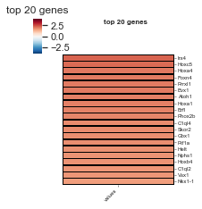

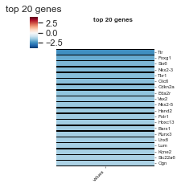

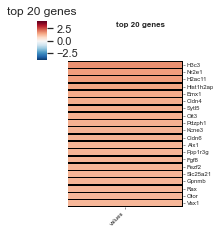

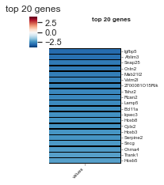

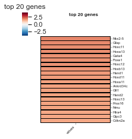

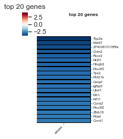

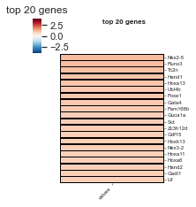

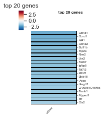

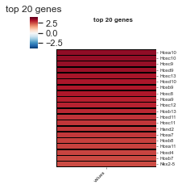

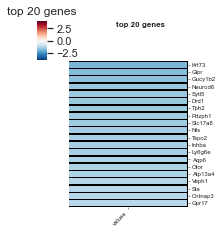

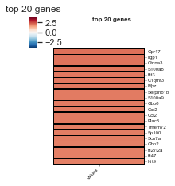

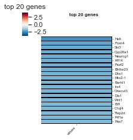

```python
# -----------------------------------------------------------------------------------
#                         Save background genes (ORA)
# -----------------------------------------------------------------------------------
n_clusters = num_nodes
with open(f'{ora_dir}background_genes_{experiment_name}_{date}.csv', 'w+') as f:
    genes = df_all[gene_id].values
    f.write(gene_id + '\n')
    for g in genes:
        f.write(f'{g}\n')

# -----------------------------------------------------------------------------------
#                         Save training genes (sig genes) (ORA)
# -----------------------------------------------------------------------------------
with open(f'{ora_dir}training-df_genes_{experiment_name}_{date}.csv', 'w+') as f:
    genes = df_training[gene_id].values
    f.write(gene_id + '\n')
    for g in genes:
        f.write(f'{g}\n')

# -----------------------------------------------------------------------------------
#                         Save genes in each of the clusters we annotated (ORA)
# -----------------------------------------------------------------------------------
for i in range(0, n_clusters):
    with open(f'{ora_dir}cluster_{i}_genes_{experiment_name}_{date}.csv', 'w+') as f:
        genes = df[gene_id].values[vae_set_idxs[i]]
        f.write(gene_id + '\n')
        for g in genes:
            f.write(f'{g}\n')

# -----------------------------------------------------------------------------------
#                         Save genes sorted by latent node (GSEA) and only the top
# -----------------------------------------------------------------------------------
def plot_top_vae_genes(vae_data_sorted, gene_ids_sorted, gene_names_sorted, label="", num=20):
        i = 0
        gs = []
        for g in gene_names_sorted:
            if g != "0":
                f.write(f'{g},{vae_data_sorted[i]}\n')
                gs.append(g)
            else:
                f.write(f'{gene_ids_sorted[i]},{vae_data_sorted[i]}\n')
                gs.append(gene_ids_sorted[i])
            i += 1
            if i >= num:
                break
        heatmap_df = pd.DataFrame()
        heatmap_df[gene_name] = gs
        heatmap_df['values'] = vae_data_sorted[:num]
        heatmap = Heatmap(heatmap_df, ['values'], gene_name, vmin=-4, vmax=4,
                  title=f'top {num} genes', cluster_cols=False, cluster_rows=False)
        heatmap.palette=sns.color_palette(sci_colour)
        heatmap.plot()
        pplot()
        save_fig(f'vae{n}_genes-top-{num}-{label}')
        plt.show()

for n in range(0, num_nodes):
    with open(f'{ora_dir}vae-{n + 1}_genes-top10_{experiment_name}_{date}.csv', 'w+') as f:
        f.write(gene_id + ',value\n')
        desc_sorted = (-vae_data[:,n]).argsort()  # Sort the genes by descending order
        gene_names_sorted = df[gene_name].values[desc_sorted]
        gene_ids_sorted = df[gene_id].values[desc_sorted]
        vae_data_sorted = vae_data[:,n][desc_sorted]
        plot_top_vae_genes(vae_data_sorted, gene_ids_sorted, gene_names_sorted, label="top")

    with open(f'{ora_dir}vae-{n + 1}_genes-bottom10_{experiment_name}_{date}.csv', 'w+') as f:
        f.write(gene_id + ',value\n')
        desc_sorted = (vae_data[:,n]).argsort()  # Sort the genes by descending order
        gene_names_sorted = df[gene_name].values[desc_sorted]
        vae_data_sorted = vae_data[:,n][desc_sorted]
        gene_ids_sorted = df[gene_id].values[desc_sorted]
        plot_top_vae_genes(vae_data_sorted, gene_ids_sorted, gene_names_sorted, label="bottom")

for n in range(0, num_nodes):
    with open(f'{ora_dir}vae-{n + 1}_{experiment_name}_{date}.csv', 'w+') as f:
        f.write(gene_id + ',value\n')
        desc_sorted = (vae_data[:,n]).argsort()  # Sort the genes by descending order
        gene_names_sorted = df[gene_id].values[desc_sorted]
        vae_data_sorted = vae_data[:,n][desc_sorted]
        for i, g in enumerate(gene_names_sorted):
            f.write(f'{g},{vae_data_sorted[i]}\n')
```

```python
# -----------------------------------------------------------------------------------
#                         Save genes in each of the clusters we annotated (ORA)
# -----------------------------------------------------------------------------------
for i in range(0, n_clusters):
    with open(f'{ora_dir}cluster_{i}_gene-names_{experiment_name}_{date}.csv', 'w+') as f:
        genes = df[gene_name].values[vae_set_idxs[i]]
        rank_vae0 = vae_data[:, 0][vae_set_idxs[i]]
        rank_vae1 = vae_data[:, 1][vae_set_idxs[i]]
        rank_vae2 = vae_data[:, 2][vae_set_idxs[i]]
        f.write(f'gene_name,VAE-1,VAE-2,VAE-3\n')
        for i, g in enumerate(genes):
            f.write(f'{g},{rank_vae0[i]},{rank_vae1[i]},{rank_vae2[i]}\n')
```

```
   H3k9me3  H3k36me3  H3k27me3  H3k27ac  H3k4me1  H3k4me2  H3k4me3  H3k9ac  \
0     0.05      0.05      0.55     0.10     0.45     0.55      0.5    0.25
1     0.05      0.00      0.55     0.05     0.45     0.50      0.5    0.15
2     0.05      0.00      0.55     0.05     0.35     0.50      0.5    0.10
3     0.10      0.00      0.55     0.05     0.55     0.60      0.5    0.20
4     0.10      0.10      0.55     0.40     0.65     0.60      0.6    0.40

        Tissue
0    Forebrain
1     Midbrain
2    Hindbrain
3  Neural-tube
4        E.F.P
```

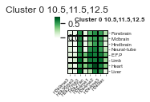

```
   H3k9me3  H3k36me3  H3k27me3  H3k27ac  H3k4me1  H3k4me2  H3k4me3  H3k9ac  \
0     0.10      0.00      0.45     0.15     0.55     0.50     0.55    0.35
1     0.00      0.05      0.55     0.05     0.20     0.45     0.45    0.10
2     0.05      0.00      0.55     0.00     0.45     0.50     0.45    0.15
3     0.00      0.00      0.50     0.05     0.40     0.50     0.45    0.10
4     0.00      0.05      0.55     0.20     0.55     0.65     0.70    0.20

        Tissue
0    Forebrain
1     Midbrain
2    Hindbrain
3  Neural-tube
4        E.F.P
```

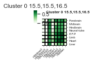

```
    H3k9me3  H3k36me3  H3k27me3   H3k27ac   H3k4me1   H3k4me2   H3k4me3  \
0  0.030769  0.061538  1.000000  0.061538  0.815385  0.830769  0.800000
1  0.030769  0.123077  1.000000  0.200000  0.738462  0.815385  0.861538
2  0.030769  0.123077  0.984615  0.507692  0.769231  0.923077  0.969231
3  0.061538  0.153846  0.800000  0.523077  0.861538  0.969231  0.953846
4  0.061538  0.107692  1.000000  0.246154  0.784615  0.846154  0.923077

     H3k9ac       Tissue
0  0.261538    Forebrain
1  0.307692     Midbrain
2  0.523077    Hindbrain
3  0.846154  Neural-tube
4  0.461538        E.F.P
```

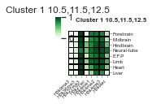

```
    H3k9me3  H3k36me3  H3k27me3   H3k27ac   H3k4me1   H3k4me2   H3k4me3  \
0  0.046154  0.046154  1.000000  0.000000  0.707692  0.692308  0.738462
1  0.061538  0.061538  0.969231  0.138462  0.615385  0.800000  0.753846
2  0.046154  0.030769  0.923077  0.446154  0.661538  0.953846  0.969231
3  0.030769  0.030769  0.707692  0.353846  0.846154  0.953846  0.907692
4  0.046154  0.030769  0.969231  0.092308  0.753846  0.846154  0.830769

     H3k9ac       Tissue
0  0.446154    Forebrain
1  0.523077     Midbrain
2  0.723077    Hindbrain
3  0.615385  Neural-tube
4  0.123077        E.F.P
```

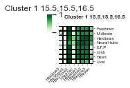

```
    H3k9me3  H3k36me3  H3k27me3   H3k27ac   H3k4me1   H3k4me2   H3k4me3  \
0  0.090909  0.189394  0.712121  0.386364  0.727273  0.803030  0.803030
1  0.106061  0.250000  0.696970  0.439394  0.636364  0.795455  0.818182
2  0.098485  0.204545  0.689394  0.636364  0.530303  0.863636  0.886364
3  0.083333  0.303030  0.515152  0.613636  0.734848  0.939394  0.901515
4  0.166667  0.287879  0.772727  0.606061  0.734848  0.840909  0.886364

     H3k9ac       Tissue
0  0.666667    Forebrain
1  0.666667     Midbrain
2  0.765152    Hindbrain
3  0.871212  Neural-tube
4  0.712121        E.F.P
```

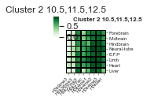

```
    H3k9me3  H3k36me3  H3k27me3   H3k27ac   H3k4me1   H3k4me2   H3k4me3  \
0  0.151515  0.090909  0.515152  0.416667  0.750000  0.765152  0.795455
1  0.159091  0.242424  0.439394  0.621212  0.553030  0.848485  0.825758
2  0.113636  0.181818  0.363636  0.787879  0.651515  0.946970  0.924242
3  0.053030  0.106061  0.287879  0.833333  0.734848  0.939394  0.893939
4  0.045455  0.106061  0.553030  0.386364  0.681818  0.840909  0.840909

     H3k9ac       Tissue
0  0.704545    Forebrain
1  0.727273     Midbrain
2  0.848485    Hindbrain
3  0.825758  Neural-tube
4  0.462121        E.F.P
```

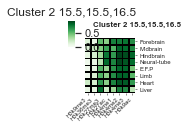

```
    H3k9me3  H3k36me3  H3k27me3   H3k27ac   H3k4me1   H3k4me2   H3k4me3  \
0  0.068966  0.103448  0.551724  0.379310  0.517241  0.586207  0.655172
1  0.068966  0.103448  0.620690  0.206897  0.620690  0.517241  0.517241
2  0.034483  0.068966  0.620690  0.103448  0.344828  0.551724  0.551724
3  0.000000  0.034483  0.655172  0.068966  0.586207  0.620690  0.517241
4  0.137931  0.103448  0.620690  0.586207  0.724138  0.689655  0.689655

     H3k9ac       Tissue
0  0.482759    Forebrain
1  0.379310     Midbrain
2  0.275862    Hindbrain
3  0.344828  Neural-tube
4  0.586207        E.F.P
```

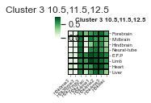

```
    H3k9me3  H3k36me3  H3k27me3   H3k27ac   H3k4me1   H3k4me2   H3k4me3  \
0  0.034483  0.034483  0.413793  0.172414  0.517241  0.448276  0.517241
1  0.034483  0.034483  0.655172  0.068966  0.379310  0.586207  0.482759
2  0.068966  0.034483  0.586207  0.000000  0.448276  0.551724  0.482759
3  0.068966  0.034483  0.482759  0.068966  0.448276  0.551724  0.482759
4  0.034483  0.000000  0.517241  0.310345  0.551724  0.655172  0.689655

     H3k9ac       Tissue
0  0.448276    Forebrain
1  0.413793     Midbrain
2  0.379310    Hindbrain
3  0.172414  Neural-tube
4  0.310345        E.F.P
```

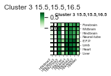

```
    H3k9me3  H3k36me3  H3k27me3   H3k27ac   H3k4me1   H3k4me2   H3k4me3  \
0  0.093407  0.543956  0.324176  0.807692  0.659341  0.934066  0.945055
1  0.115385  0.587912  0.313187  0.857143  0.697802  0.928571  0.945055
2  0.076923  0.461538  0.318681  0.895604  0.527473  0.928571  0.950549
3  0.060440  0.483516  0.252747  0.741758  0.703297  0.967033  0.945055
4  0.192308  0.670330  0.423077  0.928571  0.714286  0.956044  0.961538

     H3k9ac       Tissue
0  0.879121    Forebrain
1  0.906593     Midbrain
2  0.879121    Hindbrain
3  0.934066  Neural-tube
4  0.906593        E.F.P
```

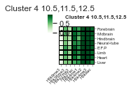

```
    H3k9me3  H3k36me3  H3k27me3   H3k27ac   H3k4me1   H3k4me2   H3k4me3  \
0  0.098901  0.208791  0.164835  0.670330  0.835165  0.868132  0.928571
1  0.109890  0.181319  0.208791  0.714286  0.714286  0.950549  0.950549
2  0.098901  0.197802  0.170330  0.708791  0.807692  0.967033  0.939560
3  0.038462  0.093407  0.175824  0.741758  0.752747  0.967033  0.934066
4  0.032967  0.324176  0.225275  0.703297  0.626374  0.950549  0.934066

     H3k9ac       Tissue
0  0.884615    Forebrain
1  0.906593     Midbrain
2  0.890110    Hindbrain
3  0.824176  Neural-tube
4  0.747253        E.F.P
```

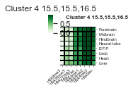

```
    H3k9me3  H3k36me3  H3k27me3   H3k27ac   H3k4me1   H3k4me2   H3k4me3  \
0  0.073171  0.024390  0.853659  0.073171  0.646341  0.658537  0.670732
1  0.012195  0.048780  0.817073  0.036585  0.609756  0.634146  0.658537
2  0.012195  0.060976  0.902439  0.060976  0.573171  0.634146  0.670732
3  0.012195  0.036585  0.841463  0.085366  0.634146  0.792683  0.731707
4  0.121951  0.073171  0.890244  0.158537  0.731707  0.719512  0.756098

     H3k9ac       Tissue
0  0.317073    Forebrain
1  0.341463     Midbrain
2  0.341463    Hindbrain
3  0.621951  Neural-tube
4  0.524390        E.F.P
```

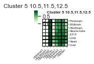

```
    H3k9me3  H3k36me3  H3k27me3   H3k27ac   H3k4me1   H3k4me2   H3k4me3  \
0  0.024390  0.048780  0.731707  0.036585  0.658537  0.658537  0.670732
1  0.036585  0.036585  0.792683  0.024390  0.585366  0.695122  0.682927
2  0.048780  0.048780  0.731707  0.036585  0.621951  0.719512  0.682927
3  0.000000  0.036585  0.670732  0.158537  0.695122  0.804878  0.768293
4  0.000000  0.024390  0.743902  0.073171  0.707317  0.756098  0.768293

     H3k9ac       Tissue
0  0.500000    Forebrain
1  0.536585     Midbrain
2  0.536585    Hindbrain
3  0.475610  Neural-tube
4  0.219512        E.F.P
```

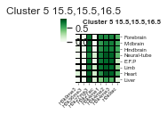

```python
import string
tissues = ['forebrain', 'midbrain', 'hindbrain', 'neural-tube',
           'embryonic-facial-prominence', 'limb',
           'heart', 'liver']
marks = ['H3K9me3', 'H3K36me3', 'H3K27me3', 'H3K27ac', 'H3K4me1', 'H3K4me2', 'H3K4me3','H3K9ac']
def get_median_naninc(df, mark, hist_metric="", time_1="", time_2="", time_3="", tissue="brain"):
    cols = []
    for c in df.columns:
        if tissue in c and mark in c and hist_metric in c and (time_1 in c or time_2 in c or time_3 in c):
            cols.append(c)
    # get nan median
    vals = np.nanmedian(df[cols].values, axis=1)
    return vals

def plot_mark_heatmap(df, idxs, title, mark_cutoff=3.0):
    mark_df = pd.DataFrame()
    mark_values = []
    mean_col = []
    if idxs is None:
        num_genes = len(df)
    else:
        num_genes = len(idxs) * 1.0
    for t in [['10.5', '11.5', '12.5'], ['15.5', '15.5', '16.5']]:
        tissue_titles = []
        marks_title = []
        for m in marks:
            mark_col = []
            for tissue in tissues:
                median_all_data = get_median_naninc(df, m, "signal", t[0], t[1], t[2], tissue)
                if idxs is None:
                    median_genes = median_all_data
                else:
                    median_genes = median_all_data[idxs]
                has_mark = 1.0 * len(np.where(median_genes > mark_cutoff)[0])
                mark_col.append(has_mark/num_genes) #np.nan_to_num(np.nanmean(median_genes)))
                if string.capwords(tissue) not in tissue_titles:
                    if tissue == 'embryonic-facial-prominence':
                        if 'E.F.P' not in tissue_titles:
                            tissue_titles.append('E.F.P')
                    else:
                        tissue_titles.append(string.capwords(tissue))
            marks_title.append(string.capwords(m))
            mark_df[string.capwords(m)] = mark_col

        mark_df['Tissue'] = tissue_titles

        heatmap = Heatmap(mark_df, marks_title, 'Tissue', vmin=0, vmax=None, cmap=hist_cmap, figsize=(2,2),
                          title=f'{title} {",".join(t)}', cluster_rows=False, cluster_cols=False)
        heatmap.plot()
        pplot()
        print(mark_df.head())
        # vmin=0, vmax=1,
        save_fig(f'mark_all_tissues_signal-{title}_{"-".join(t)}')
        plt.show()

for i, gs in enumerate(vae_set_idxs):
    plot_mark_heatmap(df, gs, f'Cluster {i}')
```

## 7) Inspecting the data in context of chromHMM annotations

Downloaded the pooled samples frmo http://enhancer.sdsc.edu/enhancer_export/ENCODE/chromHMM/pooled/ for forebrain, hindbrain, and midbrian at e16.5 on 04 December 2020.

http://enhancer.sdsc.edu/enhancer_export/ENCODE/chromHMM/readme

The files in this directory contain chromHMM chromatin state calls for multiple tissues during mouse embryonic development, as described here: http://www.biorxiv.org/content/early/2017/07/21/166652.

All files are in bed format. There is one file for each tissue at each developmental stage. The columns are 1) chromosome, 2) regions start, 3) region end, 4) chromatin state number 5) Chromatin state label. There are 15 chromating states, labeled as follows:

```
    State   Label   Description
    1   Pr-A    Promoter, Active
    2   Pr-W    Promoter, Weak/Inactive
    3   Pr-B    Promoter, Bivalent
    4   Pr-F    Promoter, Flanking
    5   En-Sd   Enhancer, Strong TSS-distal
    6   En-Sp   Enhancer, Strong TSS-proximal
    7   En-W    Enhancer, Weak TSS-distal
    8   En-Pd   Enhancer, Poised TSS-distal
    9   En-Pp   Enhancer, Poised TSS-proximal
    10  Tr-S    Transcription, Strong
    11  Tr-P    Transcription, Permissive
    12  Tr-I    Transcription, Initiation
    13  Hc-P    Heterochromatin, Polycomb-associated
    14  Hc-H    Heterochromatin, H3K9me3-associated
    15  NS  No Chromatin Signal
    NRS NRS No Reproducible State (ony relevant to "replicated" call set)
```

There are four subdirectories:

rep1\ This subdirectory contains chromatin state calls made using ChIP-seq datasets from biological replicate 1 (two biological replicates were performed for each ChIP-seq experiment).

rep2\ This subdirectory contains chromatin state calls made using ChIP-seq datasets from biological replicate 2.

replicated\ This subdirectory contains the intersection of the replicate 1 and replicate 2 chromatin state calls. Here, we require that a region is called in the same state in both replicates. If a region is not called in the same state in both replicates, it is labeled "NRS" for No Reproducible Signal. Note this is differenct than state 15, which is "No Signal."

pooled\ This subdirectory contains chromatin state calls on ChIP-seq data pooled from both replicates. We expect this will be the desired set of files for most users.

Each subdirectory has two additional subdirectorites:

archive\ This contains an older version of the bed files in which there are only state number, no labels. Aside from the labels, the files are identical to the working versions in the main directory.

tracks\ This contains bigBed versions of the files for visualization on the UCSC Genome Browser.

There is one additional subdirectory that does not conform to the templates decribed above. This is 6_mark_models. This subdirectory contains chromHMM segmentation of the e10.5 stage where we did not have all 8 marks. Note that the 11-state and 16-states models used for this segmentation are distinct from the 15-state (8-mark) model described above for the other stages. Please see manuscript and Extended Data Figure 7 for additional information.

```
    header = "chr,start,end,label,annotation"
    bed = Bed(os.path.join(self.data_dir, 'e16.5_forebrain_15_segments.bed'),
              header=None, overlap_method='in_promoter',
              output_bed_file=os.path.join(self.data_dir, 'e16.5_forebrain_15_segments_selectedPeaks.bed'),
              buffer_after_tss=0, buffer_before_tss=10, buffer_gene_overlap=0,
              gene_start=3, gene_end=4, gene_chr=2, gene_direction=5, gene_name=0,
              chr_idx=0, start_idx=1, end_idx=2, peak_value=4, header_extra="3", sep='\t'
              )
    # Add the gene annot
    bed.set_annotation_from_file(self.mm10_annot)
    # Now we can run the assign values
    bed.assign_locations_to_genes()
    bed.save_loc_to_csv(f'{self.data_dir}test_e16.5_forebrain_15_segments.csv')
```

```python
# -----------------------------------------------------------------------------------
#                         Merge information with annotations
# -----------------------------------------------------------------------------------

chrom_dir = os.path.join(supp_dir, "annot")
chromhmm_annot = pd.read_csv(f'{chrom_dir}/e16.5_forebrain_15_segments.csv')
print(len(chromhmm_annot), len(df))
# Make sure we only keep 1 annotation per gene
chromhmm_annot = chromhmm_annot.groupby('external_gene_name').first()
# Merge this with our dataframe
df = df.merge(chromhmm_annot, on='external_gene_name', how='left', suffixes=('', '_chmm'))
# Ensure the new length is the same as the old length
len(df)
```

```
53254 1371
```

```
1371
```

```
Pr-A 0.7962848297213623 1.0 [[1, 85], [19.0, 1286.0]]
Pr-W 0.0 0.25804170217693523 [[0, 147], [20.0, 1224.0]]
Pr-B 1.279485049833887 0.6074123477216837 [[6, 344], [14.0, 1027.0]]
Pr-F 0.0 0.15625224526083237 [[0, 164], [20.0, 1207.0]]
En-Sd 0.0 1.0 [[0, 7], [20.0, 1364.0]]
En-Sp 2.722672064777328 0.32615601540906763 [[1, 26], [19.0, 1345.0]]
En-W 0.0 1.0 [[0, 4], [20.0, 1367.0]]
En-Pd 0.0 1.0 [[0, 28], [20.0, 1343.0]]
En-Pp 1.9517543859649122 0.41897592979672615 [[1, 36], [19.0, 1335.0]]
Tr-S 0.0 1.0 [[0, 4], [20.0, 1367.0]]
Tr-P 1.629060579455663 0.4380407009320512 [[3, 134], [17.0, 1237.0]]
Tr-I 0.0 1.0 [[0, 15], [20.0, 1356.0]]
Hc-P 0.9616588419405321 1.0 [[2, 142], [18.0, 1229.0]]
Hc-H 0.0 1.0 [[0, 2], [20.0, 1369.0]]
NS 1.7085714285714286 0.31270297861140883 [[4, 175], [16.0, 1196.0]]
```

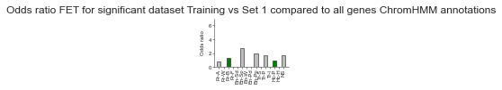

```
Pr-A 0.0 0.02927607981341397 [[0, 85], [65.0, 1286.0]]
Pr-W 0.13010204081632654 0.011080956560126786 [[1, 147], [64.0, 1224.0]]
Pr-B 3.706094627105052 4.2821828080037113e-07 [[36, 344], [29.0, 1027.0]]
Pr-F 0.11499618902439024 0.0047539914089130796 [[1, 164], [64.0, 1207.0]]
En-Sd 0.0 1.0 [[0, 7], [65.0, 1364.0]]
En-Sp 0.0 0.6275373398742911 [[0, 26], [65.0, 1345.0]]
En-W 0.0 1.0 [[0, 4], [65.0, 1367.0]]
En-Pd 0.0 0.6344854559322413 [[0, 28], [65.0, 1343.0]]
En-Pp 0.0 0.40532041814435743 [[0, 36], [65.0, 1335.0]]
Tr-S 0.0 1.0 [[0, 4], [65.0, 1367.0]]
Tr-P 0.0 0.00329487426475504 [[0, 134], [65.0, 1237.0]]
Tr-I 0.0 1.0 [[0, 15], [65.0, 1356.0]]
Hc-P 4.739604292421194 1.804454894490132e-07 [[23, 142], [42.0, 1229.0]]
Hc-H 0.0 1.0 [[0, 2], [65.0, 1369.0]]
NS 0.0 0.00030331346131901233 [[0, 175], [65.0, 1196.0]]
```

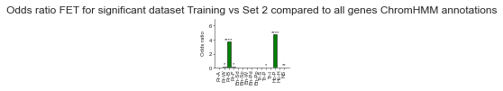

```
Pr-A 2.543883394065591 0.001692684422573647 [[19, 85], [113.0, 1286.0]]
Pr-W 1.3147153598281418 0.30748886899971783 [[18, 147], [114.0, 1224.0]]
Pr-B 0.878077975376197 0.5990814106988304 [[30, 344], [102.0, 1027.0]]
Pr-F 1.015138772077376 0.8892612091476653 [[16, 164], [116.0, 1207.0]]
En-Sd 0.0 1.0 [[0, 7], [132.0, 1364.0]]
En-Sp 2.4633699633699635 0.05517809873443448 [[6, 26], [126.0, 1345.0]]
En-W 2.6087786259541983 0.36887761444328265 [[1, 4], [131.0, 1367.0]]
En-Pd 1.4988839285714286 0.5197355286492364 [[4, 28], [128.0, 1343.0]]
En-Pp 0.5705128205128205 0.7684961913782389 [[2, 36], [130.0, 1335.0]]
Tr-S 2.6087786259541983 0.36887761444328265 [[1, 4], [131.0, 1367.0]]
Tr-P 0.3634387119520508 0.01836576583368068 [[5, 134], [127.0, 1237.0]]
Tr-I 1.3907692307692308 0.6559632934554023 [[2, 15], [130.0, 1356.0]]
Hc-P 1.545523138832998 0.10450067910740485 [[20, 142], [112.0, 1229.0]]
Hc-H 0.0 1.0 [[0, 2], [132.0, 1369.0]]
NS 0.10514285714285715 1.287858052370388e-05 [[2, 175], [130.0, 1196.0]]
```

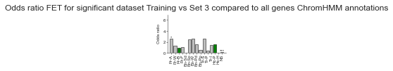

```
Pr-A 1.1206971677559914 0.7004191440669186 [[2, 85], [27.0, 1286.0]]
Pr-W 0.0 0.06480842453658792 [[0, 147], [29.0, 1224.0]]
Pr-B 0.3444767441860465 0.08145895518789259 [[3, 344], [26.0, 1027.0]]
Pr-F 0.54516711833785 0.5668581905702474 [[2, 164], [27.0, 1207.0]]
En-Sd 0.0 1.0 [[0, 7], [29.0, 1364.0]]
En-Sp 1.8475274725274726 0.4347750057777229 [[1, 26], [28.0, 1345.0]]
En-W 12.205357142857142 0.0995049371547232 [[1, 4], [28.0, 1367.0]]
En-Pd 1.7130102040816326 0.45840831149510936 [[1, 28], [28.0, 1343.0]]
En-Pp 0.0 1.0 [[0, 36], [29.0, 1335.0]]
Tr-S 0.0 1.0 [[0, 4], [29.0, 1367.0]]
Tr-P 1.4770149253731344 0.5212641556305906 [[4, 134], [25.0, 1237.0]]
Tr-I 0.0 1.0 [[0, 15], [29.0, 1356.0]]
Hc-P 3.894718309859155 0.002338662221760985 [[9, 142], [20.0, 1229.0]]
Hc-H 0.0 1.0 [[0, 2], [29.0, 1369.0]]
NS 0.5062433862433863 0.5695042237681114 [[2, 175], [27.0, 1196.0]]
```

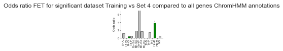

```
Pr-A 5.730837789661319 4.3733555408261855e-16 [[50, 85], [132.0, 1286.0]]
Pr-W 3.7006802721088436 1.4403180022320207e-11 [[56, 147], [126.0, 1224.0]]
Pr-B 0.24878875968992248 1.1704319647547717e-08 [[14, 344], [168.0, 1027.0]]
Pr-F 0.9599681866383881 1.0 [[21, 164], [161.0, 1207.0]]
En-Sd 0.0 1.0 [[0, 7], [182.0, 1364.0]]
En-Sp 3.007602862254025 0.006295678626757362 [[10, 26], [172.0, 1345.0]]
En-W 1.888121546961326 0.464255161493356 [[1, 4], [181.0, 1367.0]]
En-Pd 0.5329365079365079 0.5681811036579048 [[2, 28], [180.0, 1343.0]]
En-Pp 0.6215083798882681 0.6140714364837687 [[3, 36], [179.0, 1335.0]]
Tr-S 0.0 1.0 [[0, 4], [182.0, 1367.0]]
Tr-P 0.10257048092868988 8.572990310106714e-06 [[2, 134], [180.0, 1237.0]]
Tr-I 1.5150837988826815 0.45915649315318563 [[3, 15], [179.0, 1356.0]]
Hc-P 0.24448953608657595 0.000375511715419617 [[5, 142], [177.0, 1229.0]]
Hc-H 0.0 1.0 [[0, 2], [182.0, 1369.0]]
NS 0.15357945425361155 1.7525423256028567e-06 [[4, 175], [178.0, 1196.0]]
```

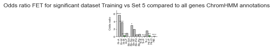

```
Pr-A 0.18678286129266522 0.0855912655610621 [[1, 85], [81.0, 1286.0]]
Pr-W 0.31619736502195817 0.039075121750396964 [[3, 147], [79.0, 1224.0]]
Pr-B 2.223218703612073 0.001045879447640467 [[35, 344], [47.0, 1027.0]]
Pr-F 0.3774233896185116 0.05046166641078755 [[4, 164], [78.0, 1207.0]]
En-Sd 0.0 1.0 [[0, 7], [82.0, 1364.0]]
En-Sp 0.0 0.3955207806103076 [[0, 26], [82.0, 1345.0]]
En-W 0.0 1.0 [[0, 4], [82.0, 1367.0]]
En-Pd 0.0 0.40057066323441465 [[0, 28], [82.0, 1343.0]]
En-Pp 0.0 0.26129178795430474 [[0, 36], [82.0, 1335.0]]
Tr-S 0.0 1.0 [[0, 4], [82.0, 1367.0]]
Tr-P 1.2821310116086235 0.44758079050816024 [[10, 134], [72.0, 1237.0]]
Tr-I 0.0 1.0 [[0, 15], [82.0, 1356.0]]
Hc-P 4.018360160965795 3.838816524468775e-07 [[26, 142], [56.0, 1229.0]]
Hc-H 0.0 1.0 [[0, 2], [82.0, 1369.0]]
NS 0.17085714285714285 0.0026615272721555185 [[2, 175], [80.0, 1196.0]]
```

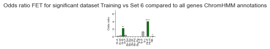

```python
# We also want to plot the annotations from gorkin et al for each of the clusters
from statsmodels.stats.multitest import multipletests

def run_annot_plot(df_bg, df_fg, title=""):
    changes = []
    order = ['Pr-A', 'Pr-W', 'Pr-B', 'Pr-F', 'En-Sd', 'En-Sp',
         'En-W', 'En-Pd', 'En-Pp', 'Tr-S', 'Tr-P', 'Tr-I',
          'Hc-P', 'Hc-H', 'NS']
    total = len(df_bg) * 1.0
    total_sig = len(df_fg) * 1.0
    perc_all = []
    perc_sig = []

    for o in order:
        o_all = len(df_bg[df_bg['peak_value'] == o])
        o_sig = len(df_fg[df_fg['peak_value'] == o])
        perc_all.append(o_all)
        perc_sig.append(o_sig)
        if o_all == 0 and o_sig == 0:
            changes.append(0)
        else:
            changes.append(((o_sig) - (o_all)))

    odds_ratios = []
    pvalues = []
    for i, o in enumerate(order):
        # Do a FET on each one
        oddsratio, pvalue = stats.fisher_exact([[perc_sig[i], perc_all[i]],
                                                [total_sig - perc_sig[i],
                                                 total - perc_all[i]]])

        print(o, oddsratio, pvalue,[[perc_sig[i], perc_all[i]],
                                                [total_sig - perc_sig[i],
                                                 total - perc_all[i]]])
        odds_ratios.append(oddsratio)
        pvalues.append(pvalue)

    reg, padj, a, b = multipletests(pvalues, alpha=0.1,
                                    method='fdr_bh', returnsorted=False)

    p_sigs = []
    for p in padj:
        if p > 0.05:
            p_sigs.append('')
        elif p <= 0.05 and p > 0.01:
            p_sigs.append('*')
        elif p <= 0.01 and p > 0.001:
            p_sigs.append('**')
        elif p <= 0.001 and p > 0.0001:
            p_sigs.append('***')
        elif p <= 0.0001:
            p_sigs.append('****')
        else:
            print(p)
            p_sigs.append('')

    fig, ax = plt.subplots(figsize=(1.5,1.0))
    c = [grey] * 14
    c[2] = "green"
    c[12] = "green"
    plt.bar(order, odds_ratios, color=c, linewidth=0.5, edgecolor='black')
    rects = ax.patches
    # Make some labels.
    labels = [f'{p_sigs[i]}' for i in range(0, len(rects))]

    for rect, label in zip(rects, labels):
        height = rect.get_height()
        ax.text(rect.get_x() + rect.get_width() / 2, height, label,
                ha='center', va='bottom')
    plt.ylim(0, 7)
    plt.yticks(np.arange(0, 7, 2.0))
    ax.set_title(f'Odds ratio FET for significant dataset {title} compared to all genes ChromHMM annotations')
    ax.set_xlabel('', fontsize=6)
    ax.set_ylabel('Odds ratio', fontsize=6)
    ax.set_xticklabels(order, rotation=90, ha="center")


    ax.tick_params(direction='out', length=2, width=0.5)
    ax.spines['bottom'].set_linewidth(0.5)
    ax.spines['top'].set_linewidth(0)
    ax.spines['left'].set_linewidth(0.5)
    ax.spines['right'].set_linewidth(0)
    ax.tick_params(labelsize=6)
    ax.tick_params(axis='x', which='major', pad=0)
    ax.tick_params(axis='y', which='major', pad=0)

    save_fig(f'OR-CM-{title}')

    plt.show()

for gene_set_label in vae_set_labels:
    run_annot_plot(df, df[df[gene_set_label] == True], title=f'Training vs {gene_set_label}')
```

```
53254 20900
Pr-A 0.16607420573205955 2.148953216275548e-92 [[85, 5950], [1286.0, 14950.0]]
Pr-W 0.5954233460773135 9.414743557547487e-10 [[147, 3508], [1224.0, 17392.0]]
Pr-B 7.495674942111099 2.2492063227528104e-139 [[344, 894], [1027.0, 20006.0]]
Pr-F 2.4410479101791274 2.9726993079622145e-20 [[164, 1102], [1207.0, 19798.0]]
En-Sd 1.572192513368984 0.22811405425132192 [[7, 68], [1364.0, 20832.0]]
En-Sp 1.1060587546986156 0.5926797643301734 [[26, 359], [1345.0, 20541.0]]
En-W 1.7443829031246734 0.3009362133436212 [[4, 35], [1367.0, 20865.0]]
En-Pd 2.157855547282204 0.00044861531889056703 [[28, 200], [1343.0, 20700.0]]
En-Pp 1.4407303370786517 0.050404632283021236 [[36, 384], [1335.0, 20516.0]]
Tr-S 0.870728393771554 1.0 [[4, 70], [1367.0, 20830.0]]
Tr-P 1.1432078804754633 0.15221518913175552 [[134, 1809], [1237.0, 19091.0]]
Tr-I 1.8384955752212389 0.032705856267117785 [[15, 125], [1356.0, 20775.0]]
Hc-P 5.861708384019851 2.776409677538453e-51 [[142, 404], [1229.0, 20496.0]]
Hc-H 0.12165696646952096 2.972537104552533e-05 [[2, 248], [1369.0, 20652.0]]
NS 0.47486730431249946 1.7301030502620268e-22 [[175, 4923], [1196.0, 15977.0]]
```

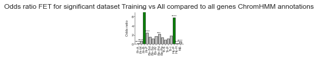

```python
df_bg = df_all.copy()  # Make a copy so we don't override the other one

# Also have a look at how the marks plot over genes that are not significant
chrom_dir = os.path.join(supp_dir, "annot")
chromhmm_annot = pd.read_csv(f'{chrom_dir}/e16.5_forebrain_15_segments.csv')
print(len(chromhmm_annot), len(df_bg))
# Make sure we only keep 1 annotation per gene
chromhmm_annot = chromhmm_annot.groupby('external_gene_name').first()
# Merge this with our dataframe
df_bg = df_bg.merge(chromhmm_annot, on='external_gene_name', how='left', suffixes=('', '_chmm'))
# Ensure the new length is the same as the old length
run_annot_plot(df_bg, df, title=f'Training vs All')
```